# Problem Set 4

Program Evaluation and Causal Inference

Christian Birchler

Fenqi Guo

Mingrui Zhang

Wenjie Tu

Zunhan Zhang

Spring Semester 2021

# Instrumental Variables

## 1. Bias of the IV estimator

$$y_i=\beta_0+\beta_1x_i+u_i$$

### 1(a)

$$\begin{aligned}
Cov(y_i,z_i)&=Cov(\beta_0+\beta_1x_i+u_i,z_i) \\
&=\beta_1Cov(x_i,z_i)+
\underbrace{Cov(u_i,z_i)}_{0} \\
&=\beta_1Cov(x_i,z_i)
\end{aligned}$$

$$\beta_1=\frac{Cov(y_i,z_i)}{Cov(x_i,z_i)}$$

where $Cov(y_i,z_i)$ can be obtained from reduced-form equation and $Cov(x_i,z_i)$ can be obtained from first-stage regression.

$$\begin{aligned}
\hat{\beta}_{IV}&=\frac{\widehat{Cov(y_i,z_i)}}{\widehat{Cov(x_i,z_i)}} \\
&=\frac{\sum_{i=1}^n(z_i-\overline{z})(y_i-\overline{y})}
{\sum_{i=1}^n(z_i-\overline{z})(x_i-\overline{x})} \\
&=\frac{\sum_{i=1}^n(z_iy_i-z_i\overline{y}-y_i\overline{z}+\overline{y}\overline{z})}
{\sum_{i=1}^n(z_ix_i-z_i\overline{x}-x_i\overline{z}+\overline{x}\overline{z})} \\
&=\frac{\sum_{i=1}^n(z_iy_i-y_i\overline{z})-\overline{y}\sum_{i=1}^nz_i+n\overline{y}\overline{z}}
{\sum_{i=1}^n(z_ix_i-x_i\overline{z})-\overline{x}\sum_{i=1}^nz_i+n\overline{x}\overline{z}} \\
&=\frac{\sum_{i=1}^n(z_iy_i-y_i\overline{z})-n\overline{y}\overline{z}+n\overline{y}\overline{z}}
{\sum_{i=1}^n(z_ix_i-x_i\overline{z})-n\overline{x}\overline{z}+n\overline{x}\overline{z}} \\
&=\frac{\sum_{i=1}^n(z_i-\overline{z})y_i}
{\sum_{i=1}^n(z_i-\overline{z})x_i}
\end{aligned}$$

### 1(b)

$$\begin{aligned}
\hat{\beta}_{IV}&=\frac{\sum_{i=1}^n(z_i-\overline{z})y_i}
{\sum_{i=1}^n(z_i-\overline{z})x_i} \\
&=\frac{\sum_{i=1}^n(z_i-\overline{z})(\beta_0+\beta_1x_i+u_i)}
{\sum_{i=1}^n(z_i-\overline{z})x_i} \\
&=\frac{\beta_0\sum_{i=1}^n(z_i-\overline{z})+
\beta_1\sum_{i=1}^n(z_i-\overline{z})x_i+\sum_{i=1}^n(z_i-\overline{z})u_i}
{\sum_{i=1}^n(z_i-\overline{z})x_i} \\
&=\beta_1+
\underbrace{\frac{\sum_{i=1}^n(z_i-\overline{z})u_i}
{\sum_{i=1}^n(z_i-\overline{z})x_i}}_\text{bias}
\end{aligned}$$

$$\begin{aligned}
\mathbb{E}\left[\hat{\beta}_{IV}\mid x_i,z_i\right]&=
\beta_1+\mathbb{E}\left[\frac{\sum_{i=1}^n(z_i-\overline{z})u_i}
{\sum_{i=1}^n(z_i-\overline{z})x_i}\middle\rvert x_i,z_i \right] \\
&=\beta_1+\frac{\sum_{i=1}^n(z_i-\overline{z})}
{\sum_{i=1}^n(z_i-\overline{z})x_i}
\underbrace{\mathbb{E}\left[u_i\mid x_i,z_i\right]}_{\neq0}
\end{aligned}$$

$\mathbb{E}\left[u_i\mid x_i,z_i\right]\neq0$ since $u_i \not\perp x_i$.

### 1(c)

$$\begin{aligned}
p\lim(\hat{\beta}_{IV}-\beta_1)&=\frac{p\lim\sum_{i=1}^n(z_i-\overline{z})u_i}
{p\lim\sum_{i=1}^n(z_i-\overline{z})x_i} \\
&=\frac{p\lim\sum_{i=1}^n(z_i-\overline{z})(u_i-\overline{u})}
{p\lim\sum_{i=1}^n(z_i-\overline{z})(x_i-\overline{x})} \\
&=\frac{p\lim\frac{1}{n}\sum_{i=1}^n(z_i-\overline{z})(u_i-\overline{u})}
{p\lim\frac{1}{n}\sum_{i=1}^n(z_i-\overline{z})(x_i-\overline{x})} \\
&\approx\frac{Cov(z_i,u_i)}{Cov(z_i, x_i)}=0
\end{aligned}$$

By *Exogeneity Assumption*, $Cov(z_i,u_i)=0$ and by *Relevance Assumption*, $Cov(z_i,x_i)\neq0$ Therefore, $\hat{\beta}_{IV}$ is a consistent estimator of $\beta_1$.

### 1(d)

In a small sample, $\hat{\beta}_{IV}$ is biased. But as the sample increases, $\beta_{IV}$ will probability converge to the $\beta_1$. Therefore, in a large sample, IV estimator will be a consistent estimator of $\beta_1$ regardless of whether there exists an endogeneity problem.

## 2. Derivation of the Wald estimator

### 2(a)

From question 1, we know that

$$\begin{aligned}
\delta^{W}=\hat{\beta}_1&=\frac{Cov(y_i,z_i)}{Cov(d_i,z_i)} \\
&=\frac{\mathbb{E}[y_i|z_i=1]-\mathbb{E}[y_i|z_i=0]}
{\mathbb{E}[d_i|z_i=1]-\mathbb{E}[d_i|z_i=0]}
\\
&=\frac{\mathbb{E}[\beta_1+\beta_1d_i+u_i|z_i=1]-\mathbb{E}[\beta_1+\beta_1d_i+u_i|z_i=0]}
{\mathbb{E}[d_i|z_i=1)-\mathbb{E}(d_i|z_i=0]} \\
&=\frac{\beta_1\mathbb{E}[d_i|z_i=1]+\mathbb{E}[u_i|z_i=1]-
\beta_1\mathbb{E}[d_i|z_i=0]-\mathbb{E}[u_i|z_i=0]}
{\mathbb{E}[d_i|z_i=1)-\mathbb{E}(d_i|z_i=0]} \\
&=\frac{\beta_1\left(\mathbb{E}[d_i|z_i=1]-\mathbb{E}[d_i|z_i=0]\right)+
\mathbb{E}[u_i|z_i=1]-\mathbb{E}[u_i|z_i=0] }
{\mathbb{E}[d_i|z_i=1]-\mathbb{E}[d_i|z_i=0]} \\
&=\beta_1+\frac{\mathbb{E}[u_i|z_i=1]-\mathbb{E}[u_i|z_i=0]}
{\mathbb{E}[d_i|z_i=1]-\mathbb{E}[d_i|z_i=0]}
\end{aligned}$$

### 2(b)

In order to identify $\beta_1$ using the instrument, we need
$$\frac{\mathbb{E}[u_i|z_i=1]-\mathbb{E}[u_i|z_i=0]}
{\mathbb{E}[d_i|z_i=1]-\mathbb{E}[d_i|z_i=0]}=0
\iff
\begin{cases}
\mathbb{E}[u_i|z_i=1]=\mathbb{E}[u_i|z_i=0] & \text{Exclusion Assumption} \\
\mathbb{E}[d_i|z_i=1]\neq\mathbb{E}[d_i|z_i=0] & \text{Relevance Assumption}
\end{cases}$$

Only relevance assumption can be tested empirically. The vadility of other assumptions must be assessed on a case-by-case basis.

## 3. Self selection revisited

### 3(a)

$$\begin{aligned}
D_i&=\pmb{1}(Y_{1i}-Y_{0i}>0) \\
&=\pmb{1}(\beta_1+u_{1i}-u_{0i}>0)
\end{aligned}$$

$$\begin{aligned}
\Delta^{\text{ATE}}&=\mathbb{E}(Y_{1i}-Y_{0i}) \\
&=\mathbb{E}[(\beta_0+\beta_1+u_{1i})-(\beta_0+u_{0i})] \\
&=\mathbb{E}(\beta_1+u_{1i}-u_{0i}) \\
&=\mathbb{E}(\beta_1)+\mathbb{E}(u_{1i})+\mathbb{E}(u_{0i}) \\
&=\beta_1>0
\end{aligned}$$

$$\begin{aligned}
\Delta^{\text{ATT}}&=\mathbb{E}(Y_{1i}-Y_{0i}\mid D=1) \\
&=\mathbb{E}(\beta_1+u_{1i}-u_{0i}\mid D=1) \\
&=\beta_1+\mathbb{E}(u_{1i}-u_{0i}\mid D=1) \\
&=\Delta^{\text{ATE}}+\mathbb{E}(u_{1i}-u_{0i}\mid D=1) \\
\mathbb{E}(u_{1i}-u_{0i}\mid D=1)&=\mathbb{E}(u_{1i}-u_{0i}\mid\beta_1+u_{1i}-u_{0i}>0) \\
&=\mathbb{E}(u_{1i}-u_{0i}\mid u_{1i}-u_{0i}>-\beta_1)>0
\end{aligned}$$
ATT is larger than ATE.

### 3(b)

$$\begin{aligned}
\Delta^{\text{naive}}&=\mathbb{E}(Y_{1i}\mid D=1)-\mathbb{E}(Y_{0i}\mid D=0)\\
&=\mathbb{E}(Y_{1i}\mid D=1)-\mathbb{E}(Y_{0i}\mid D=0)
\color{red}{-\mathbb{E}(Y_{0i}\mid D=1)+\mathbb{E}(Y_{0i}\mid D=1)} \\
&=\underbrace{\mathbb{E}(Y_{1i}\mid D=1)-\mathbb{E}(Y_{0i}\mid D=1)}_{\Delta^{\text{ATT}}}+
\underbrace{\mathbb{E}(Y_{0i}\mid D=1)-\mathbb{E}(Y_{0i}\mid D=0)}_\text{selection bias}
\end{aligned}$$

$$\begin{aligned}
\text{selection bias}&=\mathbb{E}(Y_{0i}\mid D=1)-\mathbb{E}(Y_{0i}\mid D=0) \\
&=\mathbb{E}(\beta_0+u_{0i}\mid \beta_1+u_{1i}-u_{0i}>0)-\mathbb{E}(\beta_0+u_{0i}\mid \beta_1+u_{1i}-u_{0i}\leq0) \\
&=\underbrace{\mathbb{E}(u_{0i}\mid u_{0i}<u_{1i}+\beta_1)}_\text{negative}-
\underbrace{\mathbb{E}(u_{0i}\mid u_{0i}\geq u_{1i}+\beta_1)}_\text{positive} \\
&<0
\end{aligned}$$

If individuals can self-select themselves into the program, the naive estimator will be underestimated since the selection bias is negative ($\mathbb{E}(Y_{0i}|D=1)<\mathbb{E}(Y_{0i}|D=0)$)

### 3(c)

$$\begin{cases}
D_{1i}=\pmb{1}(Y_{1i}-Y_{0i}+Z_i>0) & Z_i=1 \\
D_{0i}=\pmb{1}(Y_{1i}-Y_{0i}>0) & Z_i=0
\end{cases}$$

$$\begin{cases}
D_{1i}=\pmb{1}(u_{1i}-u_{0i}>-\beta_1-Z_i) & Z_i=1 \\
D_{0i}=\pmb{1}(u_{1i}-u_{0i}>-\beta_1) & Z_i=0
\end{cases}$$

In order to identify LATE, we need to determine the conditions for compliers. Compliers are those who are induced to switch treatment status as a result of the instrument. Therefore, D_{1i}>D_{0i}$ should hold for compliers.

$$\textrm{LATE}=\mathbb{E}(Y_{1i}-Y_{0i}\mid D_{1i}>D_{0i})$$

### 3(d)

$$D_{1i}>D_{0i}\implies
\begin{cases}
D_{1i}=1 \\
D_{0i}=0
\end{cases}\implies
\begin{cases}
u_{1i}-u_{0i}>-\beta_1-Z_1 \\
u_{1i}-u_{0i}<-\beta_1
\end{cases}\implies
-\beta_1-Z_1<u_{1i}+u_{0i}<-\beta_1$$

$$\begin{aligned}
\textrm{LATE}&=\mathbb{E}(Y_{1i}-Y_{0i}\mid D_{1i}>D_{0i}) \\
&=\beta_1+\mathbb{E}(u_{1i}-u_{0i}\mid D_{1i}>D_{0i}) \\
&=\beta_1+
\underbrace{\mathbb{E}(u_{1i}-u_{0i}\mid-\beta_1-Z_1<u_{1i}+u_{0i}<-\beta_1 )}_{<-\beta_1} \\
&<\beta_1\equiv\textrm{ATE}
\end{aligned}$$

## 4. Application: Angrist’s (1990) study on military service

### 4(b)

|  | $Z=0$ | $Z=1$ |
| --- | --- | --- |
| $D=0$ | 5,928 | 1,875 |
| $D=1$ | 1,400 | 863 |

**Due to monotonicity:**

In the observed $Z=0$ group, the individuals who received treatment ($D=1$) must be always-takers.

$$p_A=\mathbb{E}(D_i\mid Z_i=0)=
\frac{\sum_i\pmb{1}(D_i[Z_i=0]=1)}{\sum_i\pmb{1}(Z_i=0)}=
\frac{1400}{5928+1400}=0.191$$

In the observed $Z=1$ group, the individuals who did not receive treatment ($D=0$) must be never-takers.

$$p_N=1-\mathbb{E}(D_i\mid Z_i=1)=
\frac{\sum_i\pmb{1}(D_i[Z_i=1]=0)}{\sum_i\pmb{1}(Z_i=1)}=\frac{1875}{1875+863}=0.685$$

$$\begin{aligned}
p_C&=\mathbb{E}(D_i\mid Z_i=1)-\mathbb{E}(D_i\mid Z_i=0) \\
&=1-0.685-0.191 \\
&=0.124
\end{aligned}$$

**Due to randomization:**

The proportions of compliers, always-takers, and never-takers are the same between $Z=0$ and $Z=1$ group.

$$p_C=1-p_A-p_N=0.124$$

### 4(c)

|  | $Z=0$ | $Z=1$ |
| --- | --- | --- |
| $D=0$ | $\widehat{\mathbb{E}(Y)}=6.4472$ | $\widehat{\mathbb{E}(Y)}=6.4028$ |
| $D=1$ | $\widehat{\mathbb{E}(Y)}=6.4076$ | $\widehat{\mathbb{E}(Y)}=6.4289$ |

Average potential outcome for compliers:

In $Z=0$ group:

$$\underbrace{\mathbb{E}(Y_0\mid D=0,Z=0)}_{6.4472}=
\frac{p_C}{p_N+p_C}\times\mathbb{E}(Y_{0i}\mid D_{1i}>D_{0i})+
\frac{p_N}{p_N+p_C}\times\mathbb{E}(Y_{0i}\mid D_{1i}=0)$$

$$\mathbb{E}(Y_{0i}\mid D_{1i}>D_{0i})=6.6867$$

In $Z=1$ group:

$$\underbrace{\mathbb{E}(Y_1\mid D=1,Z=1)}_{6.4289}=
\frac{p_C}{p_A+p_C}\times\mathbb{E}(Y_{1i}\mid D_{1i}>D_{0i})+
\frac{p_A}{p_A+p_C}\times\mathbb{E}(Y_{1i}\mid D_{1i}=0)$$

$$\mathbb{E}(Y_{1i}\mid D_{1i}>D_{0i})=6.4616$$

### 4(d)

$$\begin{aligned}
\textrm{LATE}&=\mathbb{E}(Y_{1i}\mid D_{1i}>D_{0i})-\mathbb{E}(Y_{0i}\mid D_{1i}>D_{0i}) \\
&=6.4616-6.6867 \\
&=-0.2251
\end{aligned}$$

## 5. IV in action

### 5(a)

```r
# load relevant libraries
library(haven) # read dta file
library(lattice) # density plot
library(stargazer) # print summary statistics
library(ggplot2) # plot
library(AER) # iv regression
```

```r
d.mort <- read_dta('mortality.dta')
```

```r
demo <- subset(d.mort, select = c('before67dead', 'dist65_ageATend4emp', 'Zd_during'))
```

```r
subdata <- as.data.frame(
  subset(d.mort, select = c('before67dead', 'dist65_ageATend4emp', 'Zd_during'))
)
stargazer(subdata, header = F, title = 'Descriptive Statistics', type = 'html')
```

**Descriptive Statistics**

| Statistic | N | Mean | St. Dev. | Min | Pctl(25) | Pctl(75) | Max |
| --- | --- | --- | --- | --- | --- | --- | --- |
| before67dead | 2,298 | 0.073 | 0.260 | 0 | 0 | 0 | 1 |
| dist65_ageATend4emp | 2,298 | 6.499 | 2.248 | -5 | 5 | 8 | 11 |
| Zd_during | 2,298 | 0.479 | 0.500 | 0 | 0 | 1 | 1 |

### 5(b)

```r
model.ols1 <- lm(before67dead ~ dist65_ageATend4emp + czeit1yATage50 +
                   czeit2yATage50 + czeit5yATage50 + czeit10yATage50 +
                   czeit25yATage50 + I(czeit1yATage50^2) + I(czeit2yATage50^2) +
                   I(czeit5yATage50^2) + I(czeit10yATage50^2) +
                   I(czeit25yATage50^2) + as.factor(halfyearOFbirth) +
                   as.factor(nutsATage50), data=d.mort)

model.ols2 <- lm(before67dead ~ dist65_ageATend4emp, data=d.mort)

stargazer(model.ols1, model.ols2, keep.stat='n', header=F,
          keep='dist65_ageATend4emp', font.size='small', type = 'html',
          column.labels=c('Control', 'Non-control'), digits=4,
          title='Comparison between control and non-control')
```

**Comparison between control and non-control**

|  | *Dependent variable:* |  |
| --- | --- | --- |
|  | before67dead |  |
|  | Control | Non-control |
|  | (1) | (2) |
| dist65_ageATend4emp | 0.0046* | 0.0049** |
|  | (0.0026) | (0.0024) |
| Observations | 2,298 | 2,298 |
| *Note:* | p<0.1; p<0.05; p<0.01 |  |

### 5(c)

As we can see, the coefficient on the treatment slightly increases from column 1 (with control variables) to column 2 (without control variables).

Significance

### 5(d)

Omitted-variable bias

Health status. If people are in a bad physical condition, they are more likely to spend less years in their early retirement or even die before retirement. Therefore, the estimator for $\beta_1$ is biased upwards and we expect a positive bias.

### 5(e)

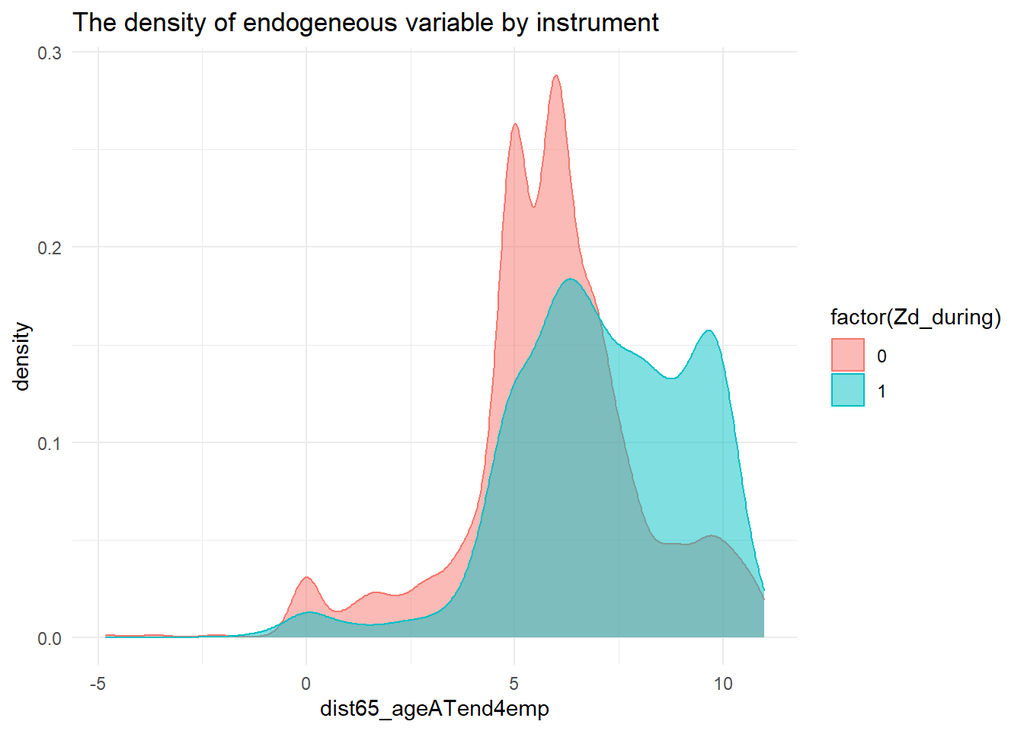

```r
ggplot(d.mort, aes(x = dist65_ageATend4emp)) +
  geom_density(aes(group = factor(Zd_during),
                   color = factor(Zd_during),
                   fill = factor(Zd_during)), alpha = 0.5) +
  theme_minimal() + ggtitle('The density of endogeneous variable by instrument')
```

### 5(f)

```r
# first stage regression
iv.1st.stage <- ivreg(dist65_ageATend4emp ~ Zd_during*as.factor(halfyearOFbirth) +
                        czeit1yATage50 + czeit2yATage50 + czeit5yATage50 +
                        czeit10yATage50 + czeit25yATage50 + I(czeit1yATage50^2) +
                        I(czeit2yATage50^2) + I(czeit5yATage50^2) + I(czeit10yATage50^2) +
                        I(czeit25yATage50^2) + as.factor(halfyearOFbirth) +
                        as.factor(nutsATage50), data=d.mort)

stargazer(iv.1st.stage, keep='Zd_during', keep.stat='n', header=F,type = 'html',
          font.size='small', title='First stage regression', no.space=T)
```

**First stage regression**

|  | *Dependent variable:* |
| --- | --- |
|  | dist65_ageATend4emp |
| Zd_during | 0.664* |
|  | (0.345) |
| Zd_during:as.factor(halfyearOFbirth)-50 | -0.448 |
|  | (0.492) |
| Zd_during:as.factor(halfyearOFbirth)-49 | -0.070 |
|  | (0.505) |
| Zd_during:as.factor(halfyearOFbirth)-48 | 0.179 |
|  | (0.506) |
| Zd_during:as.factor(halfyearOFbirth)-47 | -0.280 |
|  | (0.492) |
| Zd_during:as.factor(halfyearOFbirth)-46 | 0.424 |
|  | (0.471) |
| Zd_during:as.factor(halfyearOFbirth)-45 | 0.253 |
|  | (0.509) |
| Zd_during:as.factor(halfyearOFbirth)-44 | 0.525 |
|  | (0.504) |
| Zd_during:as.factor(halfyearOFbirth)-43 | 0.558 |
|  | (0.495) |
| Zd_during:as.factor(halfyearOFbirth)-42 | 0.150 |
|  | (0.460) |
| Zd_during:as.factor(halfyearOFbirth)-41 | 1.229*** |
|  | (0.450) |
| Zd_during:as.factor(halfyearOFbirth)-40 | 0.681 |
|  | (0.451) |
| Zd_during:as.factor(halfyearOFbirth)-39 | 0.608 |
|  | (0.463) |
| Zd_during:as.factor(halfyearOFbirth)-38 | 0.524 |
|  | (0.479) |
| Zd_during:as.factor(halfyearOFbirth)-37 | 0.345 |
|  | (0.459) |
| Observations | 2,298 |
| *Note:* | p<0.1; p<0.05; p<0.01 |

### 5(g)

```r
# second stage regression
iv.2nd.stage <- lm(before67dead ~ predict(iv.1st.stage) + czeit1yATage50 +
                     czeit2yATage50 + czeit5yATage50 + czeit10yATage50 +
                     czeit25yATage50 + I(czeit1yATage50^2) + I(czeit2yATage50^2) +
                     I(czeit5yATage50^2) + I(czeit10yATage50^2) +
                     I(czeit25yATage50^2) + as.factor(halfyearOFbirth) +
                     as.factor(nutsATage50), data=d.mort)

# iv regression
model.iv <- ivreg(before67dead ~ dist65_ageATend4emp + czeit1yATage50 +
                     czeit2yATage50 + czeit5yATage50 + czeit10yATage50 +
                     czeit25yATage50 + I(czeit1yATage50^2) + I(czeit2yATage50^2) +
                    I(czeit5yATage50^2) + I(czeit10yATage50^2) + I(czeit25yATage50^2) +
                    as.factor(halfyearOFbirth) + as.factor(nutsATage50) |
                    Zd_during*as.factor(halfyearOFbirth) + czeit1yATage50 +
                    czeit2yATage50 + czeit5yATage50 + czeit10yATage50 +
                    czeit25yATage50 + I(czeit1yATage50^2) + I(czeit2yATage50^2) +
                    I(czeit5yATage50^2) + I(czeit10yATage50^2) + I(czeit25yATage50^2) +
                    as.factor(halfyearOFbirth) + as.factor(nutsATage50), data=d.mort)

stargazer(iv.2nd.stage, model.iv, font.size='small', header=F, type = 'html',
          keep.stat=c('n', 'f'), title='Comparsion between 2SLS and ivreg',
          keep=c('iv.1st.stage', 'dist65_ageATend4emp'), digits=4)
```

**Comparsion between 2SLS and ivreg**

|  | *Dependent variable:* |  |
| --- | --- | --- |
|  | before67dead |  |
|  | *OLS* | *instrumental* |
|  |  | *variable* |
|  | (1) | (2) |
| predict(iv.1st.stage) | -0.0143 |  |
|  | (0.0109) |  |
| dist65_ageATend4emp |  | -0.0143 |
|  |  | (0.0110) |
| Observations | 2,298 | 2,298 |
| F Statistic | 1.3992* (df = 32; 2265) |  |
| *Note:* | p<0.1; p<0.05; p<0.01 |  |

As we can see, **2SLS** and **ivreg** yield exactly the same estimate but with different standard errors.

### 5(h)

```r
stargazer(model.ols1, model.iv, font.size='small', header=F,
          keep.stat=c('n', 'f'), keep='dist65_ageATend4emp', type = 'html',
          title='Comparison between OLS and 2SLS results', digits=4)
```

**Comparison between OLS and 2SLS results**

|  | *Dependent variable:* |  |
| --- | --- | --- |
|  | before67dead |  |
|  | *OLS* | *instrumental* |
|  |  | *variable* |
|  | (1) | (2) |
| dist65_ageATend4emp | 0.0046* | -0.0143 |
|  | (0.0026) | (0.0110) |
| Observations | 2,298 | 2,298 |
| F Statistic | 1.4431* (df = 32; 2265) |  |
| *Note:* | p<0.1; p<0.05; p<0.01 |  |

As expected, from column(1) to column(2), we see a decrease in the coefficient on *dist65_ageATend4emp*, which verifies our statement in 5(d) - a positive bias in the OLS estimator.